# Collecting the daily access in the SciELO Brazil collection

The [Ratchet API](http://docs.scielo.org/projects/ratchet/en/latest/api.html) has the daily access count for every journal. Our goal is to find a way to obtain and use this data.

```python
import json, re
from urllib.request import urlopen
```

```python
import matplotlib.pyplot as plt
import pandas as pd
import seaborn as sns
```

```python
%matplotlib inline
```

## Single journal access data in a DataFrame

The entry point to get the access data of a single ISSN is:

```
http://ratchet.scielo.org/api/v1/journals/<ISSN>/
```

replacing `<ISSN>` by the actual journal ISSN.

That API returns a nested JSON structure, which isn't properly fit when we're reading the data with Pandas. The function below reads the dictionary of a single journal entry (i.e., a single journal of a properly loaded JSON from Ratchet) and converts the access data to a Pandas DataFrame:

```python
def build_dataframe_from_dict(ratchet_dict):
    columns = ["total", "abstract", "html", "pdf",
               "pdfsite", "toc", "issues", "journal"]
    dicts = {
        "total": ratchet_dict,
        "pdfsite": ratchet_dict.get("other", {}).get("pdfsite", {}),
        **{key: ratchet_dict.get(key, {})
           for key in columns if key not in ["total", "pdfsite"]},
    }
    series = []
    result = pd.DataFrame()
    for key, jdata in dicts.items():
        pairs = [(pd.Timestamp(f"{pyear[1:]}-{pmonth[1:]}-{pday[1:]}"), count)
            for pyear, ydata in jdata.items()
             if re.match("y\d\d\d\d", pyear)
            for pmonth, mdata in ydata.items()
             if re.match("m\d\d", pmonth)
            for pday, count in mdata.items()
             if re.match("d\d\d", pday)
        ]
        if pairs:
            dates, counts = zip(*pairs)
            series.append(pd.Series(counts, index=dates).rename(key))
    result = pd.DataFrame(series, dtype=object).reindex(columns).T
    result[result.isna()] = 0
    return pd.DataFrame(result, dtype=int).rename_axis("date")
```

### Nauplius example

For example, let's get the access totals for [Nauplius](http://www.scielo.br/scielo.php?script=sci_serial&pid=0104-6497&lng=en&nrm=iso), whose ISSN is `0104-6497`.

```python
nauplius_url = "http://ratchet.scielo.org/api/v1/journals/0104-6497/"
nauplius_dict = json.load(urlopen(nauplius_url))
```

```python
nauplius_df = build_dataframe_from_dict(nauplius_dict)
nauplius_df.head()
```

| date | total | abstract | html | pdf | pdfsite | toc | issues | journal |
| --- | --- | --- | --- | --- | --- | --- | --- | --- |
| 2013-09-10 | 65 | 0 | 4 | 0 | 0 | 3 | 26 | 32 |
| 2013-09-11 | 17 | 0 | 1 | 0 | 0 | 1 | 6 | 9 |
| 2013-09-12 | 184 | 3 | 11 | 5 | 5 | 24 | 23 | 113 |
| 2013-09-13 | 44 | 3 | 7 | 0 | 0 | 9 | 4 | 21 |
| 2013-09-14 | 15 | 1 | 1 | 0 | 0 | 3 | 2 | 8 |

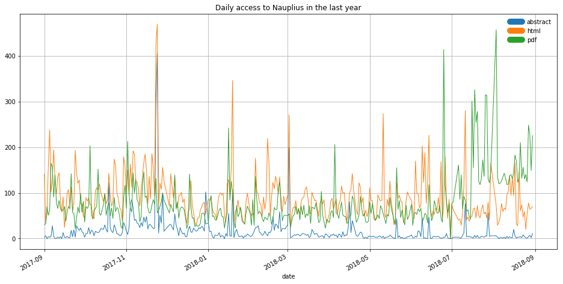

```python
nauplius_df.loc["2017-09":"2018-08", ["abstract", "html", "pdf"]].plot(
    figsize=(16, 8),
    title="Daily access to Nauplius in the last year",
    linewidth=1,
    grid=True,
)
legend = plt.gca().legend_
legend.set_frame_on(False)
for legend_line in legend.legendHandles:
    legend_line.set_linewidth(10)
    legend_line.set_solid_capstyle("round")
```

## Getting all collection journals

The entry point to get the access data of all the journals from the `scl` collection is:

```
http://ratchet.scielo.org/api/v1/general/?type=journal&collection=scl
```

However, that link is effectively broken given it'll always return a *504 - Gateway Time-out* error. Therefore, we have no alternative but to request the journals one by one.

At first, let's create a façade to directly grab the daily access DataFrame.

```python
def get_daily_accesses(issn):
    url = f"http://ratchet.scielo.org/api/v1/journals/{issn}/"
    return build_dataframe_from_dict(json.load(urlopen(url)))
```

We can get the ISSNs from either the `journals.csv` report file, or from the ArticleMeta API. Getting from the former is faster, so we'll stick with it.

```python
journals = pd.read_csv("tabs_bra/journals.csv")
issns = journals["ISSN SciELO"].unique()
len(issns)
```

```
366
```

Then we can build a tidy matrix with all the downloaded access data.

```python
%%time
accesses = pd.concat([get_daily_accesses(issn).assign(issn=issn)
                      for issn in issns])
```

```
CPU times: user 1min 12s, sys: 801 ms, total: 1min 12s
Wall time: 1min 58s
```

```python
# Save the accesses to avoid re-downloading it all
# (as of 2018-09-20, it had 38MB)
accesses.to_csv("scl_daily_access.csv")
```

```python
accesses.head()
```

| date | total | abstract | html | pdf | pdfsite | toc | issues | journal | issn |
| --- | --- | --- | --- | --- | --- | --- | --- | --- | --- |
| 2011-12-31 | 151 | 4 | 46 | 72 | 9 | 1 | 1 | 18 | 1676-5648 |
| 2012-01-01 | 180 | 3 | 54 | 96 | 8 | 3 | 2 | 14 | 1676-5648 |
| 2012-01-02 | 615 | 8 | 160 | 374 | 35 | 19 | 2 | 17 | 1676-5648 |
| 2012-01-03 | 688 | 14 | 196 | 384 | 46 | 19 | 6 | 23 | 1676-5648 |
| 2012-01-04 | 647 | 12 | 177 | 409 | 26 | 1 | 4 | 18 | 1676-5648 |

## Evaluating the access count for the entire collection

```python
collection_accesses = accesses.reset_index().groupby("date").sum()
collection_accesses
```

| date | total | abstract | html | pdf | pdfsite | toc | issues | journal |
| --- | --- | --- | --- | --- | --- | --- | --- | --- |
| 2011-12-30 | 5 | 0 | 2 | 3 | 0 | 0 | 0 | 0 |
| 2011-12-31 | 225441 | 5989 | 156060 | 43226 | 8221 | 4145 | 1830 | 5970 |
| 2012-01-01 | 152307 | 7400 | 74829 | 47314 | 8582 | 4522 | 2126 | 7534 |
| 2012-01-02 | 343623 | 7573 | 162905 | 119296 | 24075 | 10337 | 5088 | 14349 |
| 2012-01-03 | 383105 | 8967 | 180467 | 134192 | 27812 | 11660 | 5622 | 14385 |
| 2012-01-04 | 398325 | 8705 | 190284 | 139069 | 28324 | 10898 | 5705 | 15340 |
| 2012-01-05 | 396488 | 8457 | 192430 | 135552 | 27202 | 12441 | 5868 | 14538 |
| 2012-01-06 | 345391 | 8641 | 173659 | 114398 | 22035 | 9708 | 4528 | 12422 |
| 2012-01-07 | 333875 | 7174 | 207567 | 85053 | 16846 | 6057 | 2713 | 8465 |
| 2012-01-08 | 285171 | 16077 | 138494 | 88690 | 18048 | 9171 | 3540 | 11151 |
| 2012-01-09 | 494699 | 33372 | 228460 | 148660 | 32131 | 22580 | 7759 | 21737 |
| 2012-01-10 | 593908 | 69470 | 278209 | 151764 | 33066 | 29901 | 8644 | 22854 |
| 2012-01-11 | 507330 | 35529 | 232274 | 147398 | 31736 | 29530 | 8373 | 22490 |
| 2012-01-12 | 445707 | 18640 | 211135 | 141340 | 31054 | 17254 | 6664 | 19620 |
| 2012-01-13 | 378003 | 13546 | 181275 | 120512 | 26643 | 14732 | 6018 | 15277 |
| 2012-01-14 | 361575 | 20001 | 220618 | 84960 | 17658 | 7212 | 3036 | 8090 |
| 2012-01-15 | 273460 | 11428 | 134305 | 89064 | 18718 | 7808 | 2957 | 9180 |
| 2012-01-16 | 468103 | 23041 | 217976 | 148539 | 33452 | 18413 | 7020 | 19662 |
| 2012-01-17 | 498450 | 31363 | 226533 | 151281 | 35432 | 23395 | 8375 | 22071 |
| 2012-01-18 | 506176 | 31585 | 231393 | 155216 | 35368 | 22012 | 8548 | 22054 |
| 2012-01-19 | 439913 | 13640 | 211981 | 144641 | 33279 | 14515 | 6177 | 15680 |
| 2012-01-20 | 381625 | 17520 | 181394 | 119554 | 27381 | 15657 | 5259 | 14860 |
| 2012-01-21 | 368721 | 18281 | 216394 | 86868 | 19509 | 12605 | 4005 | 11059 |
| 2012-01-22 | 288466 | 12584 | 138208 | 92713 | 20645 | 9619 | 3550 | 11147 |
| 2012-01-23 | 455417 | 11364 | 211992 | 155175 | 35421 | 15156 | 6928 | 19381 |
| 2012-01-24 | 507045 | 25447 | 237568 | 155939 | 34286 | 22306 | 8631 | 22868 |
| 2012-01-25 | 500954 | 27177 | 229582 | 155120 | 33926 | 23194 | 8664 | 23291 |
| 2012-01-26 | 454778 | 16857 | 215447 | 148717 | 32590 | 16417 | 6279 | 18471 |
| 2012-01-27 | 433941 | 25181 | 204735 | 127125 | 28190 | 22850 | 6994 | 18866 |
| 2012-01-28 | 359657 | 10908 | 217473 | 88921 | 18797 | 9200 | 3787 | 10571 |
| ... | ... | ... | ... | ... | ... | ... | ... | ... |
| 2018-08-21 | 1548417 | 125385 | 653653 | 610258 | 10635 | 17549 | 9301 | 121636 |
| 2018-08-22 | 1352492 | 69731 | 549938 | 586141 | 9061 | 13445 | 8436 | 115740 |
| 2018-08-23 | 1349190 | 100246 | 549611 | 559453 | 7872 | 12443 | 7669 | 111896 |
| 2018-08-24 | 1208159 | 107687 | 486725 | 475430 | 6433 | 12337 | 7572 | 111975 |
| 2018-08-25 | 856643 | 34563 | 312899 | 383789 | 5812 | 6969 | 5386 | 107225 |
| 2018-08-26 | 1075708 | 92784 | 426287 | 426855 | 4534 | 9062 | 6143 | 110043 |
| 2018-08-27 | 1432692 | 68008 | 599682 | 619275 | 4733 | 14027 | 8412 | 118555 |
| 2018-08-28 | 1411581 | 68844 | 573298 | 623172 | 4371 | 13407 | 8249 | 120240 |
| 2018-08-29 | 1492594 | 118631 | 616353 | 611515 | 3550 | 14948 | 8260 | 119337 |
| 2018-08-30 | 1414441 | 109344 | 579403 | 583262 | 3192 | 13578 | 7660 | 118002 |
| 2018-08-31 | 895 | 62 | 425 | 319 | 5 | 4 | 5 | 75 |
| 2018-09-01 | 866528 | 38467 | 324313 | 377309 | 3917 | 6815 | 6199 | 109508 |
| 2018-09-02 | 1095764 | 91967 | 434509 | 441412 | 3137 | 7208 | 6293 | 111238 |
| 2018-09-03 | 1545886 | 129406 | 649031 | 598335 | 3660 | 35346 | 9105 | 121003 |
| 2018-09-04 | 1434437 | 85846 | 587234 | 614996 | 3785 | 13558 | 8052 | 120966 |
| 2018-09-05 | 1799870 | 264639 | 764140 | 559685 | 3471 | 56109 | 10039 | 141787 |
| 2018-09-06 | 1111364 | 50661 | 428293 | 473339 | 1982 | 11662 | 7419 | 138008 |
| 2018-09-07 | 1012653 | 80890 | 376236 | 387011 | 2317 | 31416 | 6719 | 128064 |
| 2018-09-08 | 919296 | 58981 | 327936 | 383358 | 3614 | 9742 | 6380 | 129285 |
| 2018-09-09 | 1115466 | 105025 | 430741 | 435628 | 2244 | 9315 | 5604 | 126909 |
| 2018-09-10 | 1450453 | 68993 | 623706 | 595691 | 2787 | 13911 | 8602 | 136763 |
| 2018-09-11 | 1660814 | 112587 | 749664 | 610700 | 3151 | 36688 | 8854 | 139170 |
| 2018-09-12 | 1563269 | 137942 | 654267 | 613354 | 3215 | 16643 | 9829 | 128019 |
| 2018-09-13 | 1334611 | 67464 | 548346 | 570163 | 3099 | 12932 | 8478 | 124129 |
| 2018-09-14 | 1347717 | 142803 | 522307 | 494605 | 2909 | 47186 | 10227 | 127680 |
| 2018-09-15 | 1634685 | 394595 | 640161 | 418208 | 4147 | 53105 | 6799 | 117670 |
| 2018-09-16 | 1074175 | 54021 | 430230 | 452933 | 2903 | 8758 | 6048 | 119282 |
| 2018-09-17 | 1585446 | 133221 | 675839 | 617419 | 3555 | 16602 | 8888 | 129922 |
| 2018-09-18 | 1603385 | 131722 | 670879 | 634299 | 3471 | 20976 | 8862 | 133176 |
| 2018-09-19 | 1147 | 165 | 523 | 365 | 2 | 7 | 1 | 84 |

2450 rows × 8 columns

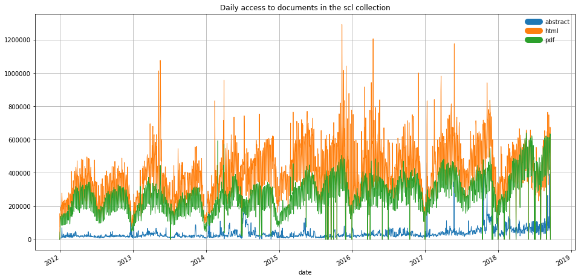

```python
collection_accesses[["abstract", "html", "pdf"]].plot(
    figsize=(16, 8),
    title="Daily access to documents in the scl collection",
    linewidth=1,
    grid=True,
)
legend = plt.gca().legend_
legend.set_frame_on(False)
for legend_line in legend.legendHandles:
    legend_line.set_linewidth(10)
    legend_line.set_solid_capstyle("round")
```

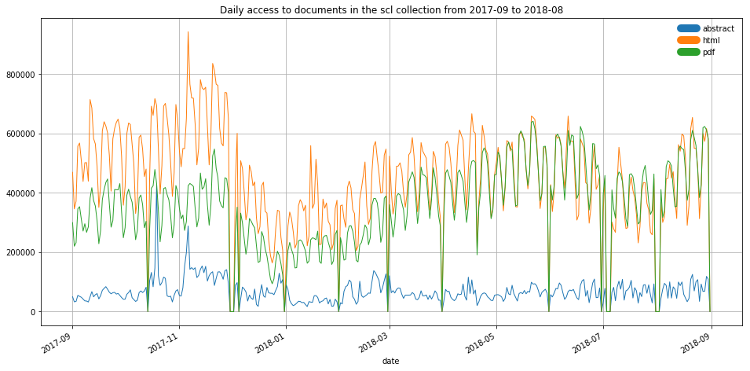

```python
collection_accesses.loc["2017-09":"2018-08", ["abstract", "html", "pdf"]].plot(
    figsize=(16, 8),
    title="Daily access to documents in the scl collection "
          "from 2017-09 to 2018-08",
    linewidth=1,
    grid=True,
)
legend = plt.gca().legend_
legend.set_frame_on(False)
for legend_line in legend.legendHandles:
    legend_line.set_linewidth(10)
    legend_line.set_solid_capstyle("round")
```

## Reproducing the SciELO Analytics Charts

In https://analytics.scielo.org we have a home/dashboard like:

[figure not shown]

Let's reproduce the left hand side of it, but the number of issues. The journal count we got from the `journals.csv`, but we could have done the same with the ArticleMeta API, which would get the current data (the notebook regarding the deindexing reason in scl has more information on how to do that).

The total accesses shown are by month. Pandas allows us to group by the year and month (using `collection_accesses.index.year` and `collection_accesses.index.month` in the `groupby`), but it also has a monthly grouper, so let's use it.

| date | total | abstract | html | pdf | pdfsite | toc | issues | journal |
| --- | --- | --- | --- | --- | --- | --- | --- | --- |
| 2018-05-31 | 36611020 | 1944622 | 15263095 | 15155345 | 95756 | 409505 | 231829 | 3510868 |
| 2018-06-30 | 34278168 | 1991711 | 13936406 | 14491219 | 67733 | 413571 | 214659 | 3162869 |
| 2018-07-31 | 26470272 | 1882551 | 9918115 | 10792576 | 81643 | 480489 | 187428 | 3127470 |
| 2018-08-31 | 33371045 | 2171366 | 13414688 | 13694333 | 180712 | 405378 | 212873 | 3291695 |
| 2018-09-30 | 24156966 | 2149395 | 9838355 | 9278810 | 57366 | 407979 | 142398 | 2282663 |

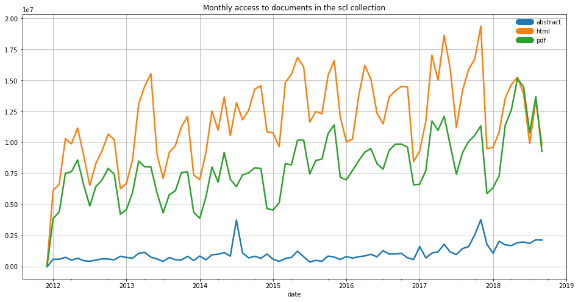

```python
monthly_data = (collection_accesses
    .groupby(pd.Grouper(freq="M"))
    .sum()
)
monthly_data[["abstract", "html", "pdf"]].plot(
    figsize=(16, 8),
    title="Monthly access to documents in the scl collection",
    linewidth=2.5,
    grid=True,
)
legend = plt.gca().legend_
legend.set_frame_on(False)
for legend_line in legend.legendHandles:
    legend_line.set_linewidth(10)
    legend_line.set_solid_capstyle("round")
monthly_data.tail()
```

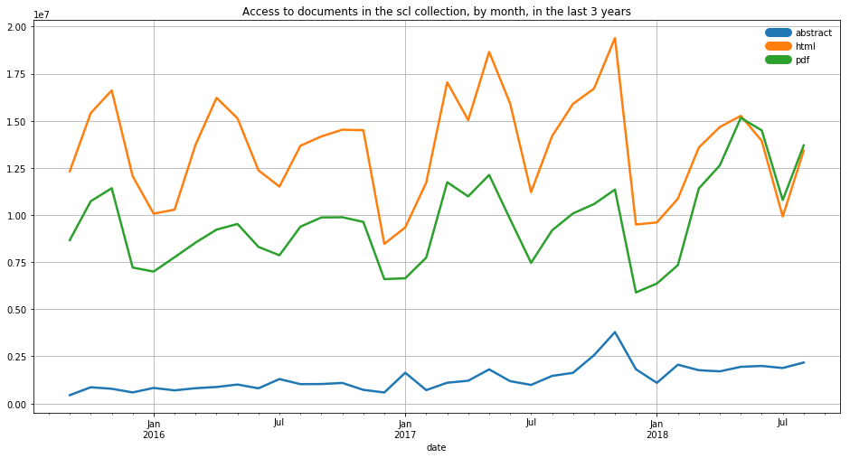

```python
monthly_data.loc["2015-09":"2018-08", ["abstract", "html", "pdf"]].plot(
    figsize=(16, 8),
    title="Access to documents in the scl collection, by month, "
          "in the last 3 years",
    linewidth=2.5,
    grid=True,
)
legend = plt.gca().legend_
legend.set_frame_on(False)
for legend_line in legend.legendHandles:
    legend_line.set_linewidth(10)
    legend_line.set_solid_capstyle("round")
```

### Week day analysis

In which day of the week does SciELO Brazil articles have more accesses?

| date | total | abstract | html | pdf | pdfsite | toc | issues | journal |
| --- | --- | --- | --- | --- | --- | --- | --- | --- |
| Sunday | 667275.151862 | 30531.512894 | 321898.217765 | 221847.630372 | 29626.472779 | 15768.830946 | 4335.234957 | 43267.252149 |
| Monday | 929982.943020 | 39583.225071 | 455172.199430 | 310183.421652 | 41974.880342 | 22807.145299 | 7481.689459 | 52780.381766 |
| Tuesday | 938702.829060 | 38615.227920 | 461691.746439 | 313432.242165 | 42595.868946 | 23383.911681 | 7319.373219 | 51664.458689 |
| Wednesday | 934482.729345 | 36531.743590 | 473964.897436 | 302749.301994 | 42004.840456 | 22194.301994 | 7123.737892 | 49913.905983 |
| Thursday | 866744.737143 | 35349.480000 | 428322.605714 | 285194.960000 | 39702.020000 | 22451.720000 | 6708.942857 | 49015.008571 |
| Friday | 760144.531609 | 32603.298851 | 371228.370690 | 247018.795977 | 34579.117816 | 21581.054598 | 6332.298851 | 46801.594828 |
| Saturday | 581277.145714 | 29985.014286 | 273333.277143 | 191460.714286 | 26959.111429 | 15213.351429 | 4160.202857 | 40165.474286 |

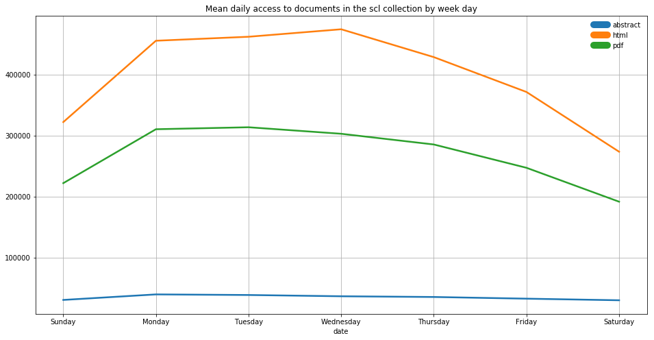

```python
collection_accesses_weekday = (
    collection_accesses.groupby([collection_accesses.index.weekday,
                                 collection_accesses.index.weekday_name])
                       .mean()
                       .reset_index(0, drop=True)
).iloc[range(-1, 6)]
collection_accesses_weekday[["abstract", "html", "pdf"]].plot(
    figsize=(16, 8),
    title="Mean daily access to documents in the scl collection by week day",
    xticks=range(7),
    linewidth=2.5,
    grid=True,
)
legend = plt.gca().legend_
legend.set_frame_on(False)
for legend_line in legend.legendHandles:
    legend_line.set_linewidth(10)
    legend_line.set_solid_capstyle("round")
collection_accesses_weekday
```

## Daily access by thematic area

As we have the data labeled for each ISSN, we can apply some filter using some information about the journal. For example, we can look for plots for each thematic area.

```python
areas = [field for field in journals.columns
               if field.startswith("title is")]
areas
```

```
['title is agricultural sciences',
 'title is applied social sciences',
 'title is biological sciences',
 'title is engineering',
 'title is exact and earth sciences',
 'title is health sciences',
 'title is human sciences',
 'title is linguistics, letters and arts',
 'title is multidisciplinary']
```

At first we need an *edge list* of all thematic areas that an ISSN is assigned to.

```python
stacked_areas = journals.set_index("ISSN SciELO")[areas].stack()
stacked_areas = (stacked_areas[stacked_areas == 1]
    .reset_index(1)["level_1"]
    .rename("area")
    .apply(lambda x: x[len("title is "):].capitalize())
    .rename_axis("issn")
    .reset_index()
)
stacked_areas.head(15)
```

|  | issn | area |
| --- | --- | --- |
| 0 | 1676-5648 | Applied social sciences |
| 1 | 0101-8108 | Health sciences |
| 2 | 0034-7701 | Human sciences |
| 3 | 0102-261X | Exact and earth sciences |
| 4 | 1516-9332 | Health sciences |
| 5 | 0104-5687 | Health sciences |
| 6 | 0103-1759 | Exact and earth sciences |
| 7 | 0101-8175 | Biological sciences |
| 8 | 0101-3122 | Agricultural sciences |
| 9 | 2179-6491 | Health sciences |
| 10 | 1980-6523 | Health sciences |
| 11 | 0373-5524 | Biological sciences |
| 12 | 0373-5524 | Exact and earth sciences |
| 13 | 0100-4239 | Biological sciences |
| 14 | 0100-4239 | Exact and earth sciences |

That can be joined with the Ratchet data, giving us the desired data to be able to plot the accesses count by thematic area.

```python
accesses_by_area = (pd.merge(accesses.reset_index(), stacked_areas)
    .groupby(["date", "area"])
    .sum()
    .stack()
    .rename("count")
    .reset_index()
    .rename(columns={"level_2": "type"})
)
accesses_by_area
```

|  | date | area | type | count |
| --- | --- | --- | --- | --- |
| 0 | 2011-12-30 | Biological sciences | total | 1 |
| 1 | 2011-12-30 | Biological sciences | abstract | 0 |
| 2 | 2011-12-30 | Biological sciences | html | 0 |
| 3 | 2011-12-30 | Biological sciences | pdf | 1 |
| 4 | 2011-12-30 | Biological sciences | pdfsite | 0 |
| 5 | 2011-12-30 | Biological sciences | toc | 0 |
| 6 | 2011-12-30 | Biological sciences | issues | 0 |
| 7 | 2011-12-30 | Biological sciences | journal | 0 |
| 8 | 2011-12-30 | Health sciences | total | 3 |
| 9 | 2011-12-30 | Health sciences | abstract | 0 |
| 10 | 2011-12-30 | Health sciences | html | 2 |
| 11 | 2011-12-30 | Health sciences | pdf | 1 |
| 12 | 2011-12-30 | Health sciences | pdfsite | 0 |
| 13 | 2011-12-30 | Health sciences | toc | 0 |
| 14 | 2011-12-30 | Health sciences | issues | 0 |
| 15 | 2011-12-30 | Health sciences | journal | 0 |
| 16 | 2011-12-30 | Human sciences | total | 2 |
| 17 | 2011-12-30 | Human sciences | abstract | 0 |
| 18 | 2011-12-30 | Human sciences | html | 1 |
| 19 | 2011-12-30 | Human sciences | pdf | 1 |
| 20 | 2011-12-30 | Human sciences | pdfsite | 0 |
| 21 | 2011-12-30 | Human sciences | toc | 0 |
| 22 | 2011-12-30 | Human sciences | issues | 0 |
| 23 | 2011-12-30 | Human sciences | journal | 0 |
| 24 | 2011-12-31 | Agricultural sciences | total | 28408 |
| 25 | 2011-12-31 | Agricultural sciences | abstract | 1330 |
| 26 | 2011-12-31 | Agricultural sciences | html | 18101 |
| 27 | 2011-12-31 | Agricultural sciences | pdf | 6296 |
| 28 | 2011-12-31 | Agricultural sciences | pdfsite | 982 |
| 29 | 2011-12-31 | Agricultural sciences | toc | 551 |
| ... | ... | ... | ... | ... |
| 176002 | 2018-09-19 | Health sciences | html | 274 |
| 176003 | 2018-09-19 | Health sciences | pdf | 212 |
| 176004 | 2018-09-19 | Health sciences | pdfsite | 0 |
| 176005 | 2018-09-19 | Health sciences | toc | 2 |
| 176006 | 2018-09-19 | Health sciences | issues | 0 |
| 176007 | 2018-09-19 | Health sciences | journal | 79 |
| 176008 | 2018-09-19 | Human sciences | total | 189 |
| 176009 | 2018-09-19 | Human sciences | abstract | 12 |
| 176010 | 2018-09-19 | Human sciences | html | 89 |
| 176011 | 2018-09-19 | Human sciences | pdf | 81 |
| 176012 | 2018-09-19 | Human sciences | pdfsite | 0 |
| 176013 | 2018-09-19 | Human sciences | toc | 4 |
| 176014 | 2018-09-19 | Human sciences | issues | 1 |
| 176015 | 2018-09-19 | Human sciences | journal | 2 |
| 176016 | 2018-09-19 | Linguistics, letters and arts | total | 11 |
| 176017 | 2018-09-19 | Linguistics, letters and arts | abstract | 0 |
| 176018 | 2018-09-19 | Linguistics, letters and arts | html | 10 |
| 176019 | 2018-09-19 | Linguistics, letters and arts | pdf | 1 |
| 176020 | 2018-09-19 | Linguistics, letters and arts | pdfsite | 0 |
| 176021 | 2018-09-19 | Linguistics, letters and arts | toc | 0 |
| 176022 | 2018-09-19 | Linguistics, letters and arts | issues | 0 |
| 176023 | 2018-09-19 | Linguistics, letters and arts | journal | 0 |
| 176024 | 2018-09-19 | Multidisciplinary | total | 18 |
| 176025 | 2018-09-19 | Multidisciplinary | abstract | 1 |
| 176026 | 2018-09-19 | Multidisciplinary | html | 10 |
| 176027 | 2018-09-19 | Multidisciplinary | pdf | 7 |
| 176028 | 2018-09-19 | Multidisciplinary | pdfsite | 0 |
| 176029 | 2018-09-19 | Multidisciplinary | toc | 0 |
| 176030 | 2018-09-19 | Multidisciplinary | issues | 0 |
| 176031 | 2018-09-19 | Multidisciplinary | journal | 0 |

176032 rows × 4 columns

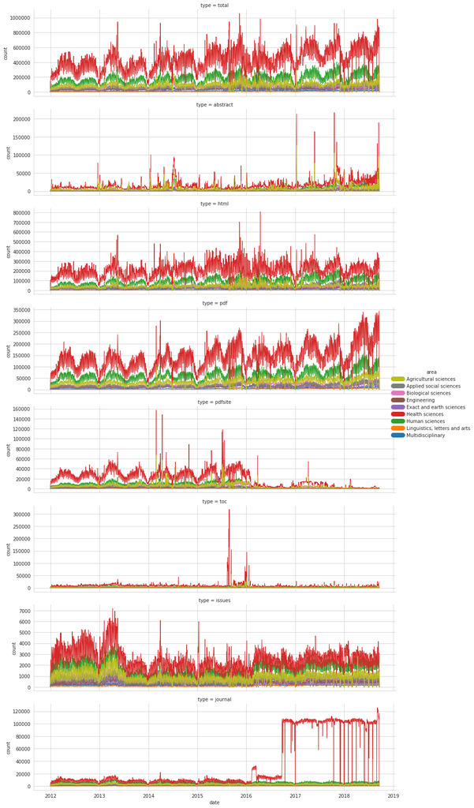

```python
areas_order = sorted(accesses_by_area["area"].unique())
with sns.axes_style("whitegrid"):
    sns.FacetGrid(accesses_by_area,
                  row="type", hue="area", hue_order=areas_order[::-1],
                  aspect=4, sharey=False) \
       .map(sns.lineplot, "date", "count", linewidth=1) \
       .add_legend(label_order=areas_order)
    for legend_line in plt.gcf().legends[0].legendHandles:
        legend_line.set_linewidth(10)
```

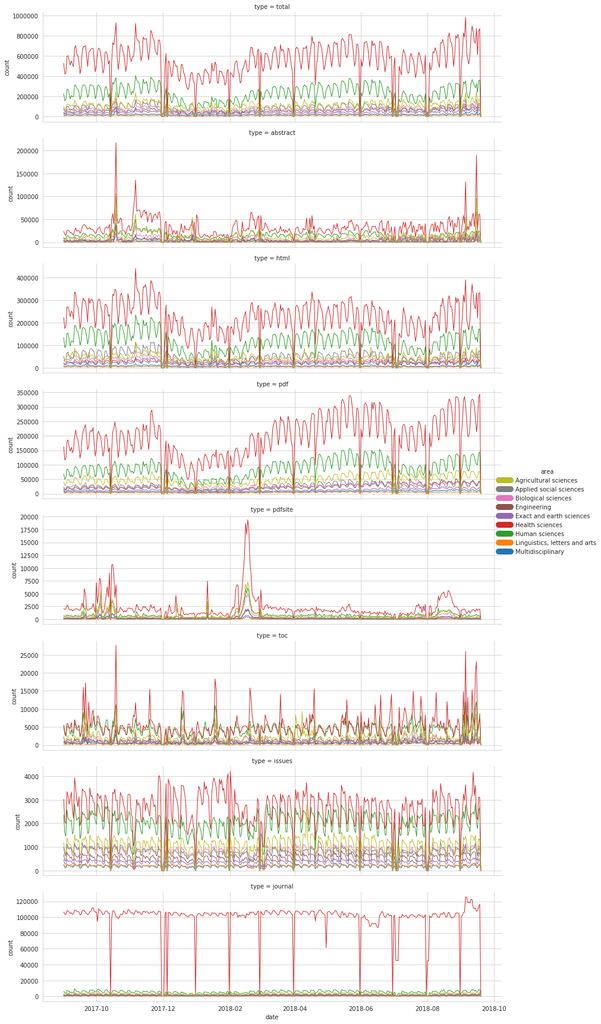

```python
with sns.axes_style("whitegrid"):
    sns.FacetGrid(accesses_by_area[accesses_by_area["date"] >= "2017-09"],
                  row="type", hue="area", hue_order=areas_order[::-1],
                  aspect=4, sharey=False) \
       .map(sns.lineplot, "date", "count", linewidth=1) \
       .add_legend(label_order=areas_order)
    for legend_line in plt.gcf().legends[0].legendHandles:
        legend_line.set_linewidth(10)
```

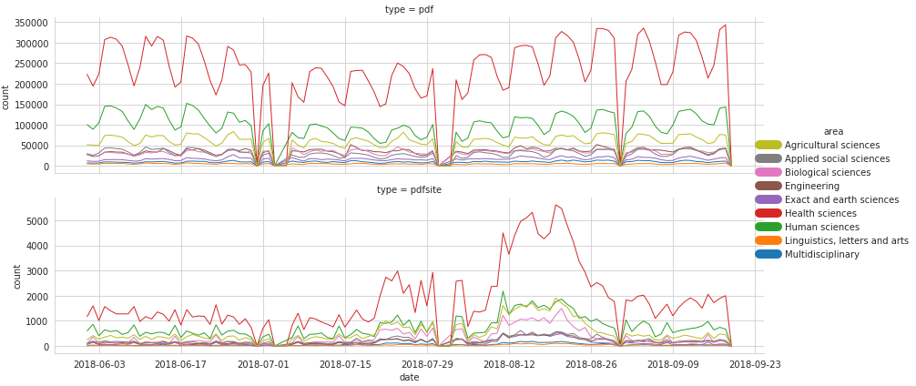

```python
with sns.axes_style("whitegrid"):
    sns.FacetGrid(accesses_by_area[
                      (accesses_by_area["date"] >= "2018-06") &
                      accesses_by_area["type"].isin(["pdf", "pdfsite"])
                  ],
                  row="type", hue="area", hue_order=areas_order[::-1],
                  aspect=4, sharey=False) \
       .map(sns.lineplot, "date", "count", linewidth=1) \
       .add_legend(label_order=areas_order)
    for legend_line in plt.gcf().legends[0].legendHandles:
        legend_line.set_linewidth(10)
```

## Accesses report

A faster approach to get access data would be the `accesses_by_journals.csv` report file. It doesn't have the daily access, but an yearly access summary.

```python
accesses_by_journals = pd.read_csv("tabs_bra/accesses_by_journals.csv")
accesses_by_journals.columns
```

```
Index(['extraction date', 'study unit', 'collection', 'ISSN SciELO', 'ISSN's',
       'title at SciELO', 'title thematic areas',
       'title is agricultural sciences', 'title is applied social sciences',
       'title is biological sciences', 'title is engineering',
       'title is exact and earth sciences', 'title is health sciences',
       'title is human sciences', 'title is linguistics, letters and arts',
       'title is multidisciplinary', 'title current status', 'publishing year',
       'accesses year', 'accesses to html', 'accesses to abstract',
       'accesses to pdf', 'accesses to epdf', 'total accesses'],
      dtype='object')
```

```python
accesses_fields = [field for field in accesses_by_journals
                         if "accesses" in field and "to" in field]
accesses_fields
```

```
['accesses to html',
 'accesses to abstract',
 'accesses to pdf',
 'accesses to epdf',
 'total accesses']
```

```python
ajdata = (accesses_by_journals
    .set_index(["accesses year"] + accesses_fields)
    [areas]
    .rename_axis("area", axis="columns")
    .stack()
    .rename("temp")
)
ajdata = ajdata[ajdata == 1].reset_index().drop(columns=["temp"])
ajdata[::5000]
```

|  | accesses year | accesses to html | accesses to abstract | accesses to pdf | accesses to epdf | total accesses | area |
| --- | --- | --- | --- | --- | --- | --- | --- |
| 0 | 2011 | 2 | 0 | 16 | 0 | 18 | title is applied social sciences |
| 5000 | 2015 | 29792 | 1331 | 13466 | 117 | 44706 | title is human sciences |
| 10000 | 2018 | 47970 | 18586 | 32856 | 53 | 99465 | title is engineering |
| 15000 | 2011 | 12 | 1 | 12 | 0 | 25 | title is engineering |
| 20000 | 2013 | 27117 | 2954 | 0 | 0 | 30071 | title is biological sciences |
| 25000 | 2011 | 22 | 3 | 9 | 0 | 34 | title is agricultural sciences |
| 30000 | 2015 | 208075 | 6624 | 91073 | 1584 | 307356 | title is health sciences |
| 35000 | 2017 | 28125 | 761 | 13861 | 11 | 42758 | title is applied social sciences |

```python
ajdata_tidy = (
    ajdata
    .groupby(["accesses year", "area"])
    .sum()
    .rename_axis("type", axis="columns")
    .stack()
    .rename("count")
    .reset_index()
    .assign(area=lambda df: df["area"].str.replace("title is ", ""),
            type=lambda df: df["type"].str.replace("accesses to ", "")
                                      .str.replace(" accesses", ""))
)
ajdata_tidy
```

|  | accesses year | area | type | count |
| --- | --- | --- | --- | --- |
| 0 | 2011 | agricultural sciences | html | 18048 |
| 1 | 2011 | agricultural sciences | abstract | 1325 |
| 2 | 2011 | agricultural sciences | pdf | 6231 |
| 3 | 2011 | agricultural sciences | epdf | 0 |
| 4 | 2011 | agricultural sciences | total | 25604 |
| 5 | 2011 | applied social sciences | html | 3827 |
| 6 | 2011 | applied social sciences | abstract | 180 |
| 7 | 2011 | applied social sciences | pdf | 1835 |
| 8 | 2011 | applied social sciences | epdf | 0 |
| 9 | 2011 | applied social sciences | total | 5842 |
| 10 | 2011 | biological sciences | html | 24371 |
| 11 | 2011 | biological sciences | abstract | 1074 |
| 12 | 2011 | biological sciences | pdf | 4769 |
| 13 | 2011 | biological sciences | epdf | 0 |
| 14 | 2011 | biological sciences | total | 30214 |
| 15 | 2011 | engineering | html | 5869 |
| 16 | 2011 | engineering | abstract | 477 |
| 17 | 2011 | engineering | pdf | 2174 |
| 18 | 2011 | engineering | epdf | 0 |
| 19 | 2011 | engineering | total | 8520 |
| 20 | 2011 | exact and earth sciences | html | 5394 |
| 21 | 2011 | exact and earth sciences | abstract | 553 |
| 22 | 2011 | exact and earth sciences | pdf | 1678 |
| 23 | 2011 | exact and earth sciences | epdf | 0 |
| 24 | 2011 | exact and earth sciences | total | 7625 |
| 25 | 2011 | health sciences | html | 105118 |
| 26 | 2011 | health sciences | abstract | 3279 |
| 27 | 2011 | health sciences | pdf | 22651 |
| 28 | 2011 | health sciences | epdf | 0 |
| 29 | 2011 | health sciences | total | 131048 |
| ... | ... | ... | ... | ... |
| 330 | 2018 | engineering | html | 5342225 |
| 331 | 2018 | engineering | abstract | 893117 |
| 332 | 2018 | engineering | pdf | 5309616 |
| 333 | 2018 | engineering | epdf | 9630 |
| 334 | 2018 | engineering | total | 11554588 |
| 335 | 2018 | exact and earth sciences | html | 4215254 |
| 336 | 2018 | exact and earth sciences | abstract | 856885 |
| 337 | 2018 | exact and earth sciences | pdf | 2865870 |
| 338 | 2018 | exact and earth sciences | epdf | 8433 |
| 339 | 2018 | exact and earth sciences | total | 7946442 |
| 340 | 2018 | health sciences | html | 50244334 |
| 341 | 2018 | health sciences | abstract | 6822204 |
| 342 | 2018 | health sciences | pdf | 47506109 |
| 343 | 2018 | health sciences | epdf | 130127 |
| 344 | 2018 | health sciences | total | 104702774 |
| 345 | 2018 | human sciences | html | 25342659 |
| 346 | 2018 | human sciences | abstract | 3333890 |
| 347 | 2018 | human sciences | pdf | 20685944 |
| 348 | 2018 | human sciences | epdf | 44039 |
| 349 | 2018 | human sciences | total | 49406532 |
| 350 | 2018 | linguistics, letters and arts | html | 1022854 |
| 351 | 2018 | linguistics, letters and arts | abstract | 125274 |
| 352 | 2018 | linguistics, letters and arts | pdf | 958338 |
| 353 | 2018 | linguistics, letters and arts | epdf | 1834 |
| 354 | 2018 | linguistics, letters and arts | total | 2108300 |
| 355 | 2018 | multidisciplinary | html | 1807694 |
| 356 | 2018 | multidisciplinary | abstract | 283093 |
| 357 | 2018 | multidisciplinary | pdf | 1710317 |
| 358 | 2018 | multidisciplinary | epdf | 4832 |
| 359 | 2018 | multidisciplinary | total | 3805936 |

360 rows × 4 columns

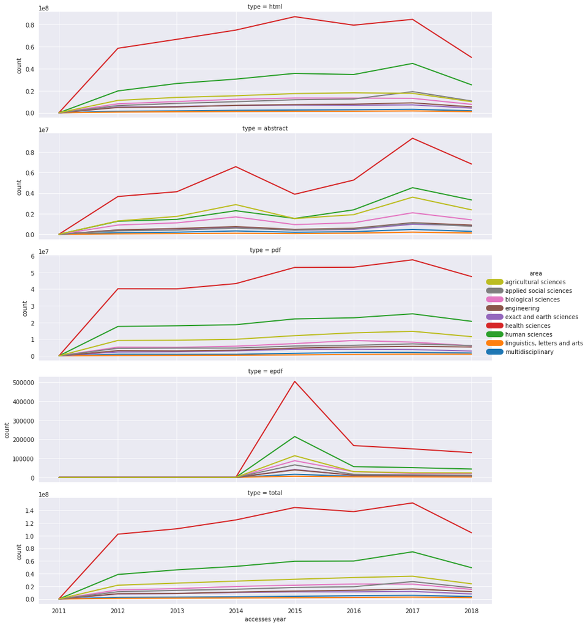

```python
label_order = sorted(ajdata_tidy["area"].unique())
with sns.axes_style("darkgrid"):
    sns.FacetGrid(ajdata_tidy,
                  row="type", hue="area", hue_order=label_order[::-1],
                  aspect=4, sharey=False) \
       .map(sns.lineplot, "accesses year", "count", linewidth=2) \
       .add_legend(label_order=label_order)
    for legend_line in plt.gcf().legends[0].legendHandles:
        legend_line.set_linewidth(10)
```

Here we have the *epdf* information and another total (the one of these $4$ types), when compared with the Ratchet API data.